# Practical Machine Learning Project Report

Bert

8 juli 2019

# Data Preprocessing

```r
library(caret)
```

```r
library(rpart)
library(rpart.plot)
library(randomForest)
```

### Downloading the Data

```r
trainUrl <-"https://d396qusza40orc.cloudfront.net/predmachlearn/pml-training.csv"
testUrl <- "https://d396qusza40orc.cloudfront.net/predmachlearn/pml-testing.csv"
trainFile <- "./data/pml-training.csv"
testFile  <- "./data/pml-testing.csv"
if (!file.exists("./data")) {
  dir.create("./data")
}
if (!file.exists(trainFile)) {
  download.file(trainUrl, destfile=trainFile)
}
if (!file.exists(testFile)) {
  download.file(testUrl, destfile=testFile)
}
```

### Reading the Data

After downloading the data from the data source, we can read the two csv files into two data frames.

```r
trainRaw <- read.csv("./data/pml-training.csv")
testRaw <- read.csv("./data/pml-testing.csv")
dim(trainRaw)
```

```
## [1] 19622   160
```

```r
#head(trainRaw)
dim(testRaw)
```

```
## [1]  20 160
```

```r
#head(testRaw)
```

The training data set has 19622 observations and 160 variables The testing data set has 20 observations and 160 variables

### Clean the data

Removing columns that contain NA missing values.

```r
trainRaw <- trainRaw[, colSums(is.na(trainRaw)) == 0]
dim(trainRaw)
```

```
## [1] 19622    93
```

```r
names(trainRaw)
```

```
##  [1] "X"                       "user_name"
##  [3] "raw_timestamp_part_1"    "raw_timestamp_part_2"
##  [5] "cvtd_timestamp"          "new_window"
##  [7] "num_window"              "roll_belt"
##  [9] "pitch_belt"              "yaw_belt"
## [11] "total_accel_belt"        "kurtosis_roll_belt"
## [13] "kurtosis_picth_belt"     "kurtosis_yaw_belt"
## [15] "skewness_roll_belt"      "skewness_roll_belt.1"
## [17] "skewness_yaw_belt"       "max_yaw_belt"
## [19] "min_yaw_belt"            "amplitude_yaw_belt"
## [21] "gyros_belt_x"            "gyros_belt_y"
## [23] "gyros_belt_z"            "accel_belt_x"
## [25] "accel_belt_y"            "accel_belt_z"
## [27] "magnet_belt_x"           "magnet_belt_y"
## [29] "magnet_belt_z"           "roll_arm"
```

[output cut: 32 more lines]

```r
testRaw <- testRaw[, colSums(is.na(testRaw)) == 0]
dim(testRaw)
```

```
## [1] 20 60
```

```r
names(testRaw)
```

```
##  [1] "X"                    "user_name"            "raw_timestamp_part_1"
##  [4] "raw_timestamp_part_2" "cvtd_timestamp"       "new_window"
##  [7] "num_window"           "roll_belt"            "pitch_belt"
## [10] "yaw_belt"             "total_accel_belt"     "gyros_belt_x"
## [13] "gyros_belt_y"         "gyros_belt_z"         "accel_belt_x"
## [16] "accel_belt_y"         "accel_belt_z"         "magnet_belt_x"
## [19] "magnet_belt_y"        "magnet_belt_z"        "roll_arm"
## [22] "pitch_arm"            "yaw_arm"              "total_accel_arm"
## [25] "gyros_arm_x"          "gyros_arm_y"          "gyros_arm_z"
## [28] "accel_arm_x"          "accel_arm_y"          "accel_arm_z"
## [31] "magnet_arm_x"         "magnet_arm_y"         "magnet_arm_z"
## [34] "roll_dumbbell"        "pitch_dumbbell"       "yaw_dumbbell"
## [37] "total_accel_dumbbell" "gyros_dumbbell_x"     "gyros_dumbbell_y"
## [40] "gyros_dumbbell_z"     "accel_dumbbell_x"     "accel_dumbbell_y"
## [43] "accel_dumbbell_z"     "magnet_dumbbell_x"    "magnet_dumbbell_y"
## [46] "magnet_dumbbell_z"    "roll_forearm"         "pitch_forearm"
## [49] "yaw_forearm"          "total_accel_forearm"  "gyros_forearm_x"
## [52] "gyros_forearm_y"      "gyros_forearm_z"      "accel_forearm_x"
## [55] "accel_forearm_y"      "accel_forearm_z"      "magnet_forearm_x"
## [58] "magnet_forearm_y"     "magnet_forearm_z"     "problem_id"
```

Removing columns that do not contribute much to the accelerometer measurements.

```r
head(trainRaw$classe)
```

```
## [1] A A A A A A
## Levels: A B C D E
```

```r
classe <- trainRaw$classe
trainRemove <- grepl("^X|timestamp|window", names(trainRaw))
trainRemove
```

```
##  [1]  TRUE FALSE  TRUE  TRUE  TRUE  TRUE  TRUE FALSE FALSE FALSE FALSE
## [12] FALSE FALSE FALSE FALSE FALSE FALSE FALSE FALSE FALSE FALSE FALSE
## [23] FALSE FALSE FALSE FALSE FALSE FALSE FALSE FALSE FALSE FALSE FALSE
## [34] FALSE FALSE FALSE FALSE FALSE FALSE FALSE FALSE FALSE FALSE FALSE
## [45] FALSE FALSE FALSE FALSE FALSE FALSE FALSE FALSE FALSE FALSE FALSE
## [56] FALSE FALSE FALSE FALSE FALSE FALSE FALSE FALSE FALSE FALSE FALSE
## [67] FALSE FALSE FALSE FALSE FALSE FALSE FALSE FALSE FALSE FALSE FALSE
## [78] FALSE FALSE FALSE FALSE FALSE FALSE FALSE FALSE FALSE FALSE FALSE
## [89] FALSE FALSE FALSE FALSE FALSE
```

```r
trainRaw <- trainRaw[, !trainRemove]
dim(trainRaw)
```

```
## [1] 19622    87
```

```r
trainCleaned <- trainRaw[, sapply(trainRaw, is.numeric)]
dim(trainCleaned)
```

```
## [1] 19622    52
```

```r
trainCleaned$classe <- classe
testRemove <- grepl("^X|timestamp|window", names(testRaw))
testRaw <- testRaw[, !testRemove]
testCleaned <- testRaw[, sapply(testRaw, is.numeric)]
dim(testCleaned)
```

```
## [1] 20 53
```

The training data set has 19622 observations and 53 remaining variables The testing data set has 20 observations and remaining 53 variables

### Split the data

Splitting the cleaned training set into a pure training data set (70%) and a validation data set (30%). Validation data will be used to conduct cross validation in future steps.

```r
set.seed(100) # For reproducibile purpose
inTrain <- createDataPartition(trainCleaned$classe, p=0.70, list=FALSE)
trainData <- trainCleaned[inTrain, ]
dim(trainData)
```

```
## [1] 13737    53
```

```r
testData <- trainCleaned[-inTrain, ]
dim(testData)
```

```
## [1] 5885   53
```

## Data Modeling

Using Random Forest algorithm to fit a predictive model for activity recognition. Random Forest automatically selects important variables and is robust to correlated covariates & outliers in general. A **3-fold cross validation and ntree = 100** is chosen when applying the algorithm.

```r
controlRf <- trainControl(method="cv", 3)
modelRf <- train(classe ~ ., data=trainData, method="rf", trControl=controlRf, ntree=100)
modelRf
```

```
## Random Forest
##
## 13737 samples
##    52 predictor
##     5 classes: 'A', 'B', 'C', 'D', 'E'
##
## No pre-processing
## Resampling: Cross-Validated (3 fold)
## Summary of sample sizes: 9158, 9159, 9157
## Resampling results across tuning parameters:
##
##   mtry  Accuracy   Kappa
##    2    0.9866787  0.9831456
##   27    0.9879160  0.9847122
##   52    0.9788169  0.9731963
##
## Accuracy was used to select the optimal model using the largest value.
## The final value used for the model was mtry = 27.
```

Estimation performance of the model on the validation data set.

```r
predictRf <- predict(modelRf, testData)
confusionMatrix(testData$classe, predictRf)
```

```
## Confusion Matrix and Statistics
##
##           Reference
## Prediction    A    B    C    D    E
##          A 1674    0    0    0    0
##          B    7 1131    1    0    0
##          C    0    4 1021    1    0
##          D    0    2   15  947    0
##          E    0    0    2    1 1079
##
## Overall Statistics
##
##                Accuracy : 0.9944
##                  95% CI : (0.9921, 0.9961)
##     No Information Rate : 0.2856
##     P-Value [Acc > NIR] : < 2.2e-16
##
##                   Kappa : 0.9929
##
##  Mcnemar's Test P-Value : NA
##
## Statistics by Class:
##
##                      Class: A Class: B Class: C Class: D Class: E
## Sensitivity            0.9958   0.9947   0.9827   0.9979   1.0000
## Specificity            1.0000   0.9983   0.9990   0.9966   0.9994
## Pos Pred Value         1.0000   0.9930   0.9951   0.9824   0.9972
## Neg Pred Value         0.9983   0.9987   0.9963   0.9996   1.0000
## Prevalence             0.2856   0.1932   0.1766   0.1613   0.1833
## Detection Rate         0.2845   0.1922   0.1735   0.1609   0.1833
## Detection Prevalence   0.2845   0.1935   0.1743   0.1638   0.1839
## Balanced Accuracy      0.9979   0.9965   0.9908   0.9972   0.9997
```

```r
accuracy <- data.frame(postResample(predictRf, testData$classe))
accuracy
```

```
##          postResample.predictRf..testData.classe.
## Accuracy                                0.9943925
## Kappa                                   0.9929060
```

```r
oose <- 1 - as.numeric(confusionMatrix(testData$classe, predictRf)$overall[1])
oose
```

```
## [1] 0.005607477
```

Estimated accuracy of the model is 99.44% and the estimated out-of-sample error is 0.56%.

## Predicting for Test Data Set

Applying the model to the original testing data set downloaded from the data source. We remove the `problem_id` column first.

```r
result <- predict(modelRf, testCleaned[, -length(names(testCleaned))])
result
```

```
##  [1] B A B A A E D B A A B C B A E E A B B B
## Levels: A B C D E
```

## Appendix: Figures

Decision Tree Visualization

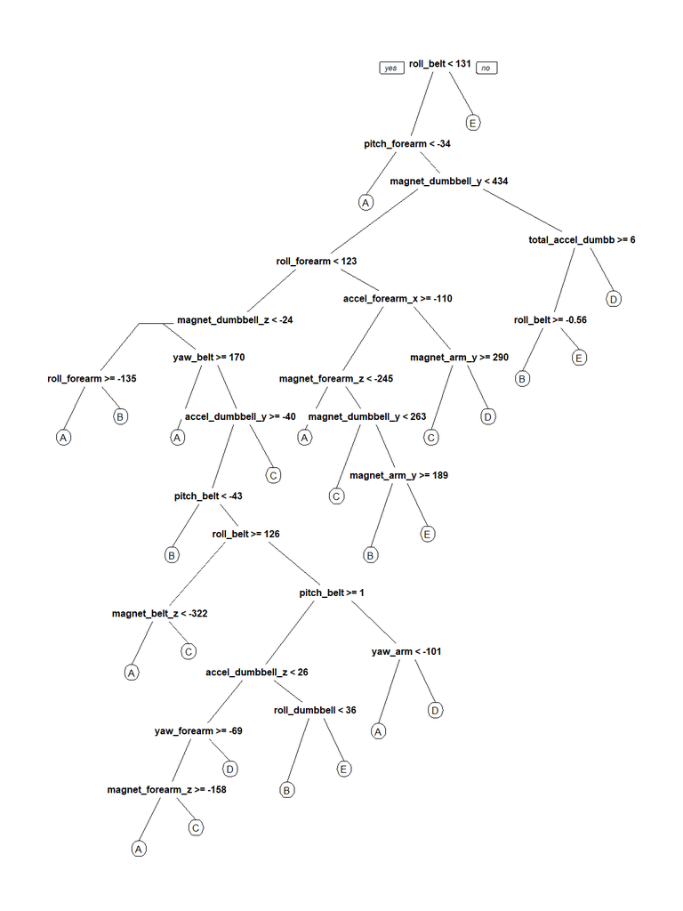

```r
treeModel <- rpart(classe ~ ., data=trainData, method="class")
prp(treeModel)
```